# Table des matières

Télécharger bloc-note Jupyter  
*"Clic droit --> Enregistrer le lien sous"*

# Indexation des données en tables

## Consulter les données dans un fichier csv

> Vous allez manipuler les données de deux tables de données contenant des informations concernant les monuments nationaux français.  
> Ces deux tables sont construites de la façon suivante : (source [www.data.gouv.fr](https://www.data.gouv.fr/fr/organizations/centre-des-monuments-nationaux/))

| Fichier "monuments_frequentation.csv" : |
| --- |
| id nom frequentation |
| id : numéro de l'enregistrement nom : nom du monument frequentation : nombre de visiteurs en 2012 |

**ET**

| Fichier "monuments_GPS.csv" : |
| --- |
| id nom lat long |
| id : numéro de l'enregistrement nom : nom du monument lat : latitude du monument long : longitude du monument |

**Fichiers à télécharger**

- Clic droit --> Enregistrer le lien sous..
- Enregistrer les 3 fichiers dans le même dossier
- Créer un fichier Pyhton dans lequel vous recopierez les bouts de codes ci-dessous

monuments_frequentation.csv  
monuments_GPS.csv  
tables.py

#### Dans la suite du document un **seul** programme Python est présenté par petits morceaux !

### Import des bibliothèques

Pour la suite du travail vous aurez besoin des bibiliothèques csv, tables.

```python
import csv
import tables
```

### Récupérer les en-têtes

à partir d'un fichier .csv sous la forme d'une liste Python.

```python
entetes = next(open('monuments_GPS.csv', newline='')).rstrip('\r\n').split(',')
entetes
```

```
['id', 'nom', 'lat', 'long']
```

### Lire les données

d'un fichier .csv sous la forme d'un dictionnaire Python.  
rappel : un dictionnaire est une structure de données présentée sous la forme : `{clé_1: valeur_1 ; clé_2: valeur_2}`

```python
import csv
csv_file = open('monuments_GPS.csv', "r")
reader = csv.DictReader(csv_file)

for row in reader:
    print(dict(row))

csv_file.close()
```

```
{'id': '1', 'nom': 'Abbaye de Beaulieu-en-Rouergue', 'lat': '44.2012986', 'long': '1.8576953'}
{'id': '2', 'nom': 'Abbaye de Charroux', 'lat': '46.141736', 'long': '0.404965'}
{'id': '3', 'nom': 'Abbaye de Cluny', 'lat': '46.43517292', 'long': '4.658219218'}
{'id': '4', 'nom': 'Abbaye de La Sauve-Majeure', 'lat': '44.7679', 'long': '-0.3125'}
{'id': '5', 'nom': 'Abbaye de Montmajour', 'lat': '43.70567881', 'long': '4.664148241'}
{'id': '6', 'nom': 'Abbaye du Bec-Hellouin', 'lat': '49.228611', 'long': '0.721667'}
{'id': '7', 'nom': 'Abbaye du Mont-Saint-Michel', 'lat': '48.63597158', 'long': '-1.511414051'}
{'id': '8', 'nom': 'Abbaye du Thoronet', 'lat': '43.4501102', 'long': '6.3080895'}
{'id': '9', 'nom': 'Alignements de Carnac', 'lat': '47.597702', 'long': '-3.0633934'}
{'id': '10', 'nom': 'Arc de triomphe', 'lat': '48.873818', 'long': '2.295023'}
{'id': '11', 'nom': 'Basilique cathédrale de Saint-Denis', 'lat': '48.93541968', 'long': '2.35991478'}
{'id': '12', 'nom': 'Cairn de Barnenez', 'lat': '48.66756914', 'long': '-3.858427405'}
{'id': '13', 'nom': 'Cathédrale de Besançon et son horloge astronomique', 'lat': '47.2336343', 'long': '6.0303255'}
{'id': '14', 'nom': 'Chapelle expiatoire', 'lat': '48.8736986', 'long': '2.322691083'}
{'id': '15', 'nom': "Château d'Angers", 'lat': '47.4698136', 'long': '-0.5593384'}
{'id': '16', 'nom': "Château d'Assier", 'lat': '44.6752839', 'long': '1.8792255'}
{'id': '17', 'nom': "Château d'Aulteribe", 'lat': '45.775', 'long': '3.498889'}
{'id': '18', 'nom': "Château d'Azay-le-Rideau", 'lat': '47.2595533', 'long': '0.4666037'}
{'id': '19', 'nom': "Château d'If", 'lat': '43.27985713', 'long': '5.325134397'}
{'id': '20', 'nom': "Château d'Oiron", 'lat': '46.95187347', 'long': '-0.07733345'}
{'id': '21', 'nom': 'Château de Bouges', 'lat': '47.04240481', 'long': '1.672968864'}
{'id': '22', 'nom': 'Château de Bussy-Rabutin', 'lat': '47.56157768', 'long': '4.523475766'}
{'id': '23', 'nom': 'Château de Cadillac', 'lat': '44.63810122', 'long': '-0.320652723'}
{'id': '24', 'nom': 'Château de Carrouges', 'lat': '48.56012908', 'long': '-0.154345036'}
{'id': '25', 'nom': 'Château de Castelnau-Bretenoux', 'lat': '44.8992', 'long': '1.8256'}
{'id': '26', 'nom': 'Château de Chareil-Cintrat', 'lat': '46.23942016', 'long': '3.229722977'}
{'id': '27', 'nom': 'Château de Châteaudun', 'lat': '48.07079562', 'long': '1.323723793'}
{'id': '28', 'nom': 'Château de Coucy', 'lat': '49.52177486', 'long': '3.318611383'}
{'id': '29', 'nom': 'Château de Fougères-sur-Bièvre', 'lat': '47.44773885', 'long': '1.343808174'}
{'id': '30', 'nom': 'Château de Gramont', 'lat': '43.9580329', 'long': '0.9211763'}
{'id': '31', 'nom': 'Château de La Motte-Tilly', 'lat': '48.46713457', 'long': '3.431473374'}
{'id': '32', 'nom': 'Château de Montal', 'lat': '44.8624197', 'long': '1.8599192'}
{'id': '33', 'nom': 'Château de Pierrefonds', 'lat': '49.34699376', 'long': '2.980197072'}
{'id': '34', 'nom': 'Château de Puyguilhem', 'lat': '45.425833', 'long': '0.744444'}
{'id': '35', 'nom': 'Château de Rambouillet et Laiterie de la Reine et Chaumière aux Coquillages', 'lat': '48.64540401', 'long': '1.817328036'}
{'id': '36', 'nom': 'Château de Talcy', 'lat': '47.76975536', 'long': '1.444476843'}
{'id': '37', 'nom': 'Château de Villeneuve-Lembron', 'lat': '45.47799655', 'long': '3.185970783'}
{'id': '38', 'nom': 'Château de Vincennes', 'lat': '48.84266825', 'long': '2.435703278'}
{'id': '39', 'nom': 'Château de Voltaire à Ferney', 'lat': '46.2581309', 'long': '6.1043544'}
{'id': '40', 'nom': 'Château et remparts de la cité de Carcassonne', 'lat': '43.20728336', 'long': '2.363262177'}
```

[output cut: 20 more lines]

```
{'id': '61', 'nom': 'Site archéologique de Glanum', 'lat': '43.7736', 'long': '4.833'}
{'id': '62', 'nom': 'Site archéologique de Montcaret', 'lat': '44.8587327', 'long': '0.0638404'}
{'id': '63', 'nom': "Site archéologique et musée d'Ensérune", 'lat': '43.310556', 'long': '3.115278'}
{'id': '64', 'nom': 'Site des mégalithes de Locmariaquer', 'lat': '47.5732972', 'long': '-2.9574633'}
{'id': '65', 'nom': 'Site gallo-romain de Sanxay', 'lat': '46.4941324', 'long': '-0.0070385'}
{'id': '66', 'nom': 'Tour et crypte de la cathédrale de Bourges', 'lat': '47.08241152', 'long': '2.398495674'}
{'id': '67', 'nom': 'Tour Pey-Berland à Bordeaux', 'lat': '44.8379962', 'long': '-0.5777064'}
{'id': '68', 'nom': "Tours de la cathédrale d'Amiens", 'lat': '49.895', 'long': '2.302222'}
{'id': '69', 'nom': 'Tours de la cathédrale de Chartres', 'lat': '48.44776369', 'long': '1.487982273'}
{'id': '70', 'nom': 'Tours de la cathédrale de Reims', 'lat': '49.2534', 'long': '4.033'}
{'id': '71', 'nom': 'Tours de la cathédrale Notre-Dame de Paris', 'lat': '48.85297618', 'long': '2.349953055'}
{'id': '72', 'nom': 'Tours de La Rochelle', 'lat': '46.15580101', 'long': '-1.153231859'}
{'id': '73', 'nom': "Tours et remparts d'Aigues-Mortes", 'lat': '43.56781436', 'long': '4.190865755'}
{'id': '74', 'nom': "Trophée d'Auguste à La Turbie", 'lat': '43.74480501', 'long': '7.401840091'}
{'id': '75', 'nom': 'Villa Savoye à Poissy', 'lat': '48.92442556', 'long': '2.028270364'}
```

Dans l'exemple précédent, chaque ligne est vue par Python comme une donnée indépendant du reste du fichier. Dans la réalité nous préférerons un élément(une variable) qui contient toutes les données. Nous utiliserons pour cela une liste de dictionnaires.

```python
import csv

reader = csv.DictReader(open('monuments_GPS.csv', 'r'))
monuments = []
for row in reader:
    monuments.append(dict(row))

print(monuments)
```

[output not shown]

On peut l'écrire de manière plus conscise à l'aide d'une liste par compréhension.

```python
import csv

reader = csv.DictReader(open('monuments_GPS.csv', 'r'))
monuments = [dict(ligne) for ligne in reader]
```

### Projection

- Réaliser une projection pour obtenir une liste contenant le numéro des monuments ainsi que leur nom :

```python
tables.projection('monuments_GPS.csv',"id, nom")
```

```
[{'id': '1', 'nom': 'Abbaye de Beaulieu-en-Rouergue'},
 {'id': '2', 'nom': 'Abbaye de Charroux'},
 {'id': '3', 'nom': 'Abbaye de Cluny'},
 {'id': '4', 'nom': 'Abbaye de La Sauve-Majeure'},
 {'id': '5', 'nom': 'Abbaye de Montmajour'},
 {'id': '6', 'nom': 'Abbaye du Bec-Hellouin'},
 {'id': '7', 'nom': 'Abbaye du Mont-Saint-Michel'},
 {'id': '8', 'nom': 'Abbaye du Thoronet'},
 {'id': '9', 'nom': 'Alignements de Carnac'},
 {'id': '10', 'nom': 'Arc de triomphe'},
 {'id': '11', 'nom': 'Basilique cathédrale de Saint-Denis'},
 {'id': '12', 'nom': 'Cairn de Barnenez'},
 {'id': '13', 'nom': 'Cathédrale de Besançon et son horloge astronomique'},
 {'id': '14', 'nom': 'Chapelle expiatoire'},
 {'id': '15', 'nom': "Château d'Angers"},
 {'id': '16', 'nom': "Château d'Assier"},
 {'id': '17', 'nom': "Château d'Aulteribe"},
 {'id': '18', 'nom': "Château d'Azay-le-Rideau"},
 {'id': '19', 'nom': "Château d'If"},
 {'id': '20', 'nom': "Château d'Oiron"},
 {'id': '21', 'nom': 'Château de Bouges'},
 {'id': '22', 'nom': 'Château de Bussy-Rabutin'},
 {'id': '23', 'nom': 'Château de Cadillac'},
 {'id': '24', 'nom': 'Château de Carrouges'},
 {'id': '25', 'nom': 'Château de Castelnau-Bretenoux'},
 {'id': '26', 'nom': 'Château de Chareil-Cintrat'},
 {'id': '27', 'nom': 'Château de Châteaudun'},
 {'id': '28', 'nom': 'Château de Coucy'},
 {'id': '29', 'nom': 'Château de Fougères-sur-Bièvre'},
 {'id': '30', 'nom': 'Château de Gramont'},
 {'id': '31', 'nom': 'Château de La Motte-Tilly'},
 {'id': '32', 'nom': 'Château de Montal'},
 {'id': '33', 'nom': 'Château de Pierrefonds'},
 {'id': '34', 'nom': 'Château de Puyguilhem'},
 {'id': '35',
  'nom': 'Château de Rambouillet et Laiterie de la Reine et Chaumière aux Coquillages'},
 {'id': '36', 'nom': 'Château de Talcy'},
 {'id': '37', 'nom': 'Château de Villeneuve-Lembron'},
 {'id': '38', 'nom': 'Château de Vincennes'},
 {'id': '39', 'nom': 'Château de Voltaire à Ferney'},
```

[output cut: 21 more lines]

```
 {'id': '61', 'nom': 'Site archéologique de Glanum'},
 {'id': '62', 'nom': 'Site archéologique de Montcaret'},
 {'id': '63', 'nom': "Site archéologique et musée d'Ensérune"},
 {'id': '64', 'nom': 'Site des mégalithes de Locmariaquer'},
 {'id': '65', 'nom': 'Site gallo-romain de Sanxay'},
 {'id': '66', 'nom': 'Tour et crypte de la cathédrale de Bourges'},
 {'id': '67', 'nom': 'Tour Pey-Berland à Bordeaux'},
 {'id': '68', 'nom': "Tours de la cathédrale d'Amiens"},
 {'id': '69', 'nom': 'Tours de la cathédrale de Chartres'},
 {'id': '70', 'nom': 'Tours de la cathédrale de Reims'},
 {'id': '71', 'nom': 'Tours de la cathédrale Notre-Dame de Paris'},
 {'id': '72', 'nom': 'Tours de La Rochelle'},
 {'id': '73', 'nom': "Tours et remparts d'Aigues-Mortes"},
 {'id': '74', 'nom': "Trophée d'Auguste à La Turbie"},
 {'id': '75', 'nom': 'Villa Savoye à Poissy'}]
```

### Sélection

- Réaliser une sélection pour obtenir une liste contenant les monuments des le nom contient "Château" :

```python
tables.select('monuments_frequentation.csv',"'château' in ligne['nom'] or 'Château' in ligne['nom']")
```

```
[{'id': '15', 'nom': "Château d'Angers", 'frequentation': '166533'},
 {'id': '16', 'nom': "Château d'Assier", 'frequentation': '3948'},
 {'id': '17', 'nom': "Château d'Aulteribe", 'frequentation': '6693'},
 {'id': '18', 'nom': "Château d'Azay-le-Rideau", 'frequentation': '293594'},
 {'id': '19', 'nom': "Château d'If", 'frequentation': '90584'},
 {'id': '20', 'nom': "Château d'Oiron", 'frequentation': '20035'},
 {'id': '21', 'nom': 'Château de Bouges', 'frequentation': '11608'},
 {'id': '22', 'nom': 'Château de Bussy-Rabutin', 'frequentation': '31940'},
 {'id': '23', 'nom': 'Château de Cadillac', 'frequentation': '11071'},
 {'id': '24', 'nom': 'Château de Carrouges', 'frequentation': '22907'},
 {'id': '25',
  'nom': 'Château de Castelnau-Bretenoux',
  'frequentation': '47494'},
 {'id': '26', 'nom': 'Château de Chareil-Cintrat', 'frequentation': '2018'},
 {'id': '27', 'nom': 'Château de Châteaudun', 'frequentation': '20615'},
 {'id': '28', 'nom': 'Château de Coucy', 'frequentation': '14528'},
 {'id': '29',
  'nom': 'Château de Fougères-sur-Bièvre',
  'frequentation': '17227'},
 {'id': '30', 'nom': 'Château de Gramont', 'frequentation': '4681'},
 {'id': '31', 'nom': 'Château de La Motte-Tilly', 'frequentation': '4111'},
 {'id': '32', 'nom': 'Château de Montal', 'frequentation': '17713'},
 {'id': '33', 'nom': 'Château de Pierrefonds', 'frequentation': '134568'},
 {'id': '34', 'nom': 'Château de Puyguilhem', 'frequentation': '15361'},
 {'id': '35',
  'nom': 'Château de Rambouillet et Laiterie de la Reine et Chaumière aux Coquillages',
  'frequentation': '28418'},
 {'id': '36', 'nom': 'Château de Talcy', 'frequentation': '13453'},
 {'id': '37', 'nom': 'Château de Villeneuve-Lembron', 'frequentation': '6975'},
 {'id': '38', 'nom': 'Château de Vincennes', 'frequentation': '139155'},
 {'id': '39', 'nom': 'Château de Voltaire à Ferney', 'frequentation': '10536'},
 {'id': '40',
  'nom': 'Château et remparts de la cité de Carcassonne',
  'frequentation': '471707'}]
```

- Réaliser une sélection pour obtenir une liste des monuments dont la fréquentation dépasse les 100 000 visiteurs :

```python
tables.select('monuments_frequentation.csv',"100000 < int(ligne['frequentation'])")
```

```
[{'id': '3', 'nom': 'Abbaye de Cluny', 'frequentation': '124110'},
 {'id': '7', 'nom': 'Abbaye du Mont-Saint-Michel', 'frequentation': '1270506'},
 {'id': '8', 'nom': 'Abbaye du Thoronet', 'frequentation': '107935'},
 {'id': '10', 'nom': 'Arc de triomphe', 'frequentation': '1732280'},
 {'id': '11',
  'nom': 'Basilique cathédrale de Saint-Denis',
  'frequentation': '171441'},
 {'id': '15', 'nom': "Château d'Angers", 'frequentation': '166533'},
 {'id': '18', 'nom': "Château d'Azay-le-Rideau", 'frequentation': '293594'},
 {'id': '33', 'nom': 'Château de Pierrefonds', 'frequentation': '134568'},
 {'id': '38', 'nom': 'Château de Vincennes', 'frequentation': '139155'},
 {'id': '40',
  'nom': 'Château et remparts de la cité de Carcassonne',
  'frequentation': '471707'},
 {'id': '45', 'nom': 'Conciergerie', 'frequentation': '456589'},
 {'id': '46',
  'nom': 'Domaine national de Saint-Cloud',
  'frequentation': '141019'},
 {'id': '58', 'nom': 'Panthéon', 'frequentation': '724392'},
 {'id': '60', 'nom': 'Sainte-Chapelle', 'frequentation': '951807'},
 {'id': '71',
  'nom': 'Tours de la cathédrale Notre-Dame de Paris',
  'frequentation': '494283'},
 {'id': '72', 'nom': 'Tours de La Rochelle', 'frequentation': '119033'},
 {'id': '73',
  'nom': "Tours et remparts d'Aigues-Mortes",
  'frequentation': '167051'}]
```

### Longueur

- Retrouver le nombre de monuments nationaux :

```python
tables.longueur('monuments_frequentation.csv')
```

```
75
```

## Carte interactive

Créer une page html affichant une carte intéractive des monuments nationaux.  
La page affichera une vue de la France métropolitaine avec un marqueur à l'emplacement de chaque monument.  
Le marqueur sera de couleur différente suivant la fréquentation :

[output not shown]

Pour les plus avancés :

Compléter la carte en ajoutant :

1) Une bulle de survol sur chaque marqueur indiquant le nom du monument.  
2) Une légende (au clic) qui rappellera le nom du monument et le nombre de visiteurs.  
3) Une image du monument à la légende. (les images ne s'affichent pas sur l'aperçu dans la console)

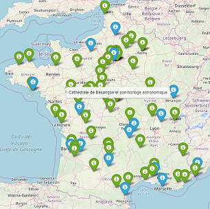

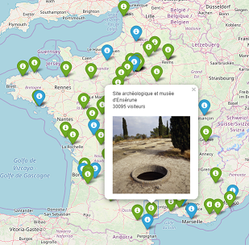

### Ressources

[Documentation Folium](https://python-visualization.github.io/folium/quickstart.html)  
[Dossier images monuments](https://github.com/mickaelSASL/www/blob/main/1/TDT/1/images_monuments.zip?raw=true)